# DES_part3_03735990

## Task 3.2: Verification

```python
%run "part3_tests"
```

```
.
----------------------------------------------------------------------
Ran 1 test in 0.920s

OK
```

## Task 3.2.1: Verification of distributions

```python
import part3_simstudy
```

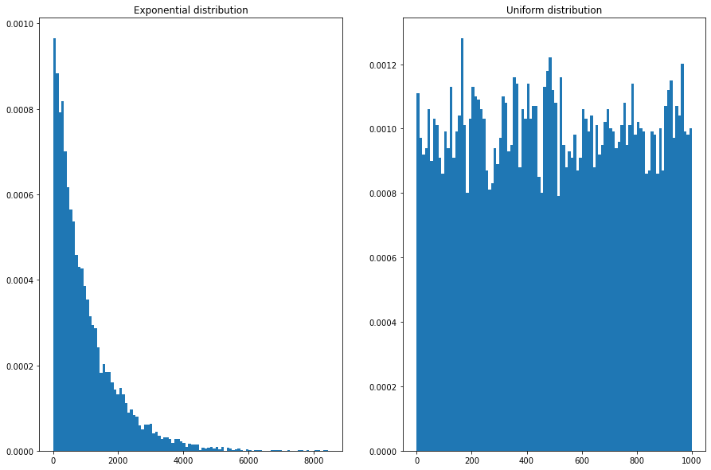

```python
part3_simstudy.task_3_2_1()
```

## Task 3.2.2: Verification of system utilization

```
Simulation time: 100.0 sec and buffer size: 5
Theoretical RHO: 0.01 Observed RHO: 0.010
Theoretical RHO: 0.5 Observed RHO: 0.497
Theoretical RHO: 0.8 Observed RHO: 0.738
Theoretical RHO: 0.9 Observed RHO: 0.801
Done!
Simulation time: 1000.0 sec and buffer size: 5
Theoretical RHO: 0.01 Observed RHO: 0.010
Theoretical RHO: 0.5 Observed RHO: 0.496
Theoretical RHO: 0.8 Observed RHO: 0.745
Theoretical RHO: 0.9 Observed RHO: 0.806
Done!
```

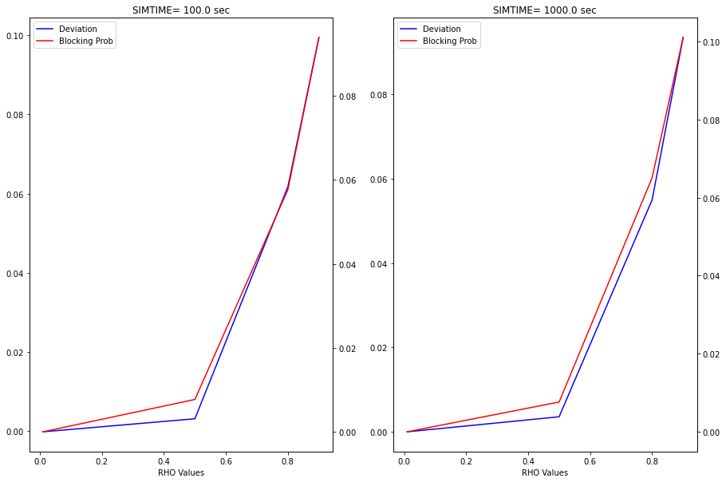

```python
part3_simstudy.task_3_2_2()
```

# Task 3.3 Analysis and General Questions

## Task 3.3.1: Seed for Random Number Generation

Simulating non-deterministic system can still be considered as running an 'experiment'. The seed to the RNG in the non-deterministic system allows us to check the repeatability and reproducibility of our 'experiment'.Even though this causes the RNG to not be truly random, a large number of simulation runs should emulate the randomness of the real world for our experiment.

## Task 3.3.2 Bins for Histogram

There exists no definite rule for the number of bins to be used for a histogram. A common 'rule of thumb' is that if the number of samples is large enough, the number of bins should be roughly the square root of the number of samples. If we decrease the number of bins, we get a more 'block like' distribution which does not have the sensitivity to exactly depict the curves required in distributons like exponential or gaussian. If we increase the number of bins, we start seeing the granularity in the distribution and it has more 'peaks and valleys' than necessary. We will also have empty spaces if no values from our sample falls inside an unnecassarily small bin

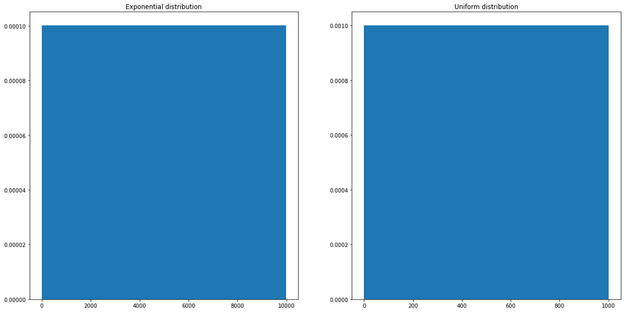

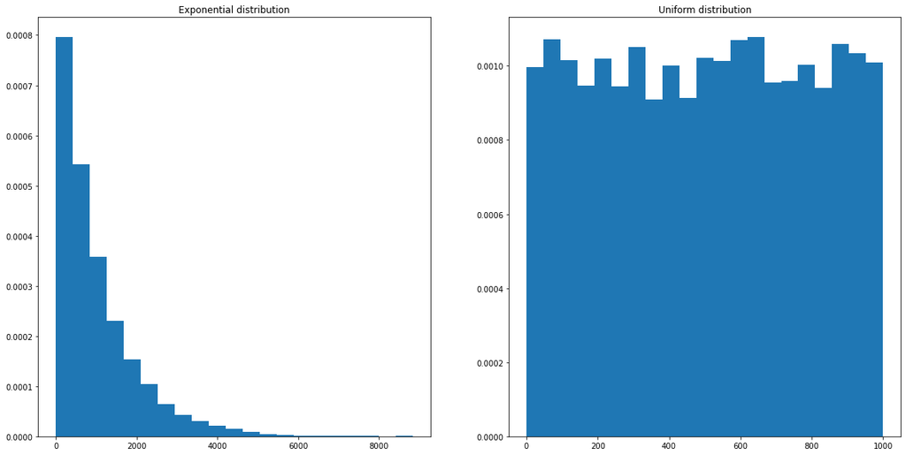

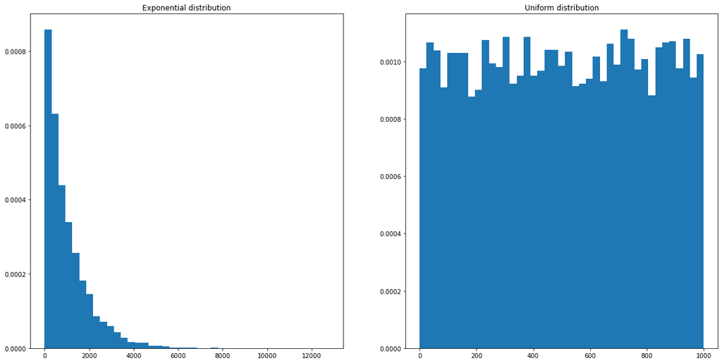

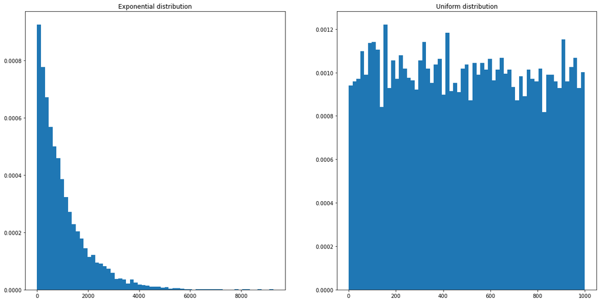

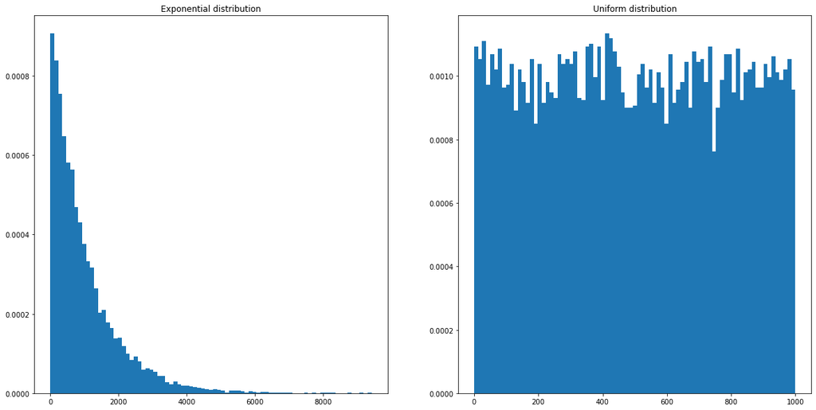

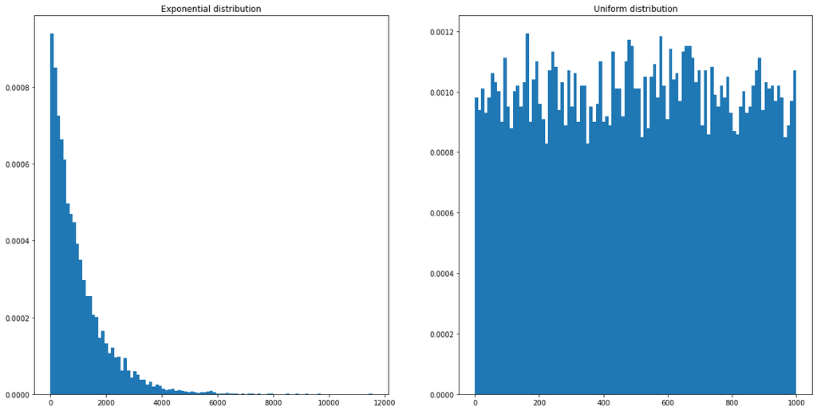

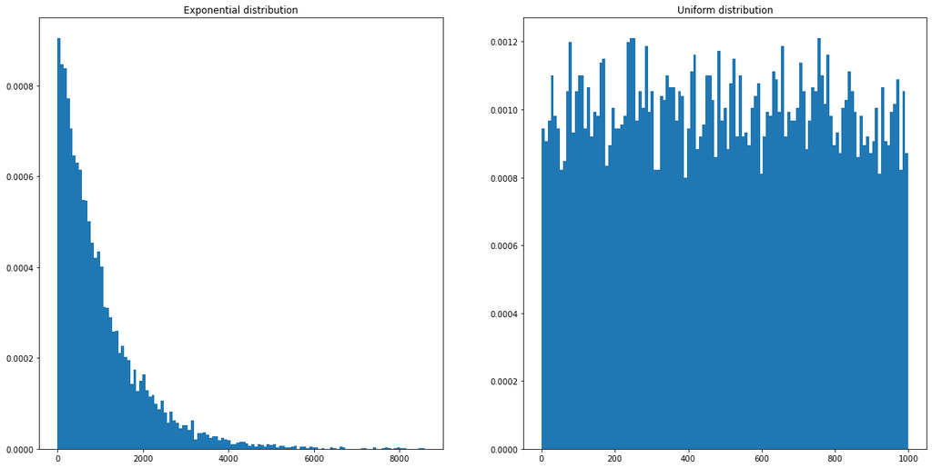

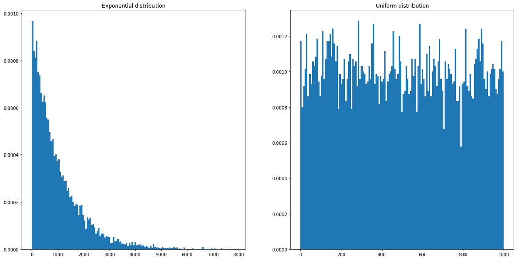

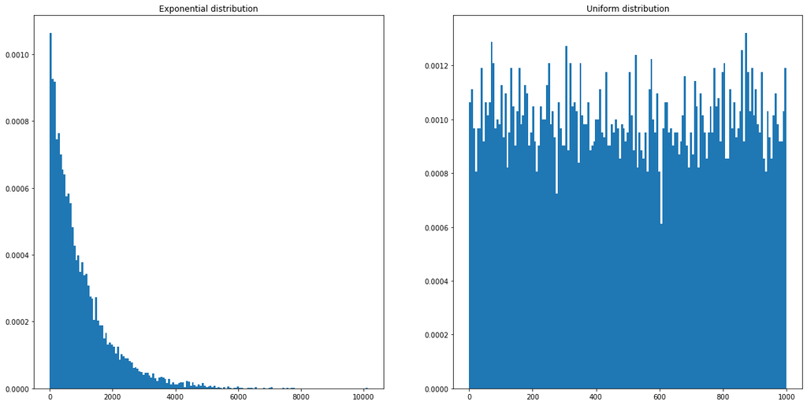

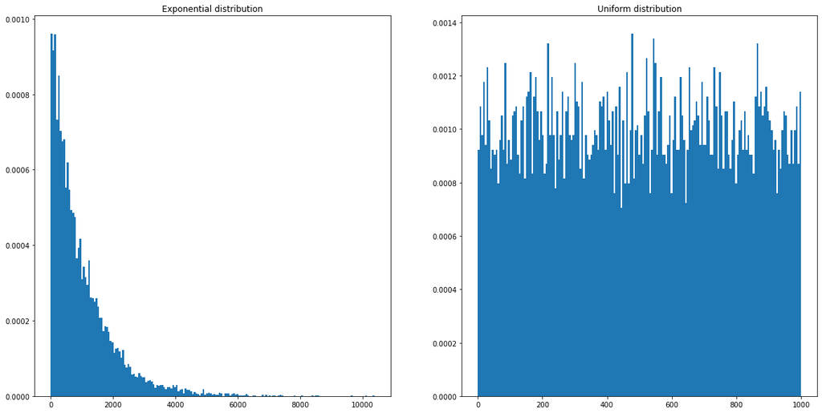

```python
part3_simstudy.task_3_3_2()
```